# Introduction to CohortSymmetry

CohortSymmetry provides tools to perform Sequence Symmetry Analysis (SSA). Before using the package, it is highly recommended that this method is tested beforehand against a selection of positive and negative controls on a users specific database.

The functions you will interact with are:

1. `sequenceCohort()`: this function will create a cohort with individuals present in both (the index and the marker) cohorts.
2. `summariseSequenceRatios()`: this function will calculate sequence ratios.
3. `tableSequenceRatios()` and `plotSequenceRatios()`: these functions will help us to visualise the sequence ratio results.
4. `summariseTemporalSymmetry()`: this function will produce aggregated results based on the time difference between two cohort start dates.
5. `plotTemporalSymmetry()`: this function will help us to visualise the results from summariseTemporalSymmetry().

Below, you will find an example analysis that offers a brief and comprehensive overview of the package’s functionalities. More context and further examples for each of these functions are provided in later vignettes.

First, let’s load the relevant libraries.

```r
library(omock)
library(CohortSymmetry)
library(visOmopResults)
library(dplyr)
```

The CohortSymmetry package works with data mapped to the OMOP CDM. Hence, the initial step involves connecting to a database which is user and database specific. As an example, we will be using omock package which can call various synthetic databases. We will use the GIBleed data to create two cohorts: the **index_cohort** and the **marker_cohort**.

```r
library(dplyr)
library(CodelistGenerator)
library(CohortConstructor)

cdm <- mockCdmFromDataset(datasetName = "GiBleed")

index_codelist <- CodelistGenerator::getDrugIngredientCodes(
  cdm = cdm,
  name = "aspirin",
  nameStyle = "{concept_name}"
)

cdm[["index"]] <- CohortConstructor::conceptCohort(
  cdm = cdm,
  conceptSet = index_codelist,
  exit = "event_end_date",
  name = "index")


marker_codelist <- CodelistGenerator::getDrugIngredientCodes(
  cdm = cdm,
  name = "amoxicillin",
  nameStyle = "{concept_name}"
)

cdm[["marker"]] <- CohortConstructor::conceptCohort(
  cdm = cdm,
  conceptSet = marker_codelist,
  exit = "event_end_date",
  name = "marker")
```

Once we have our data and created the index and marker cohorts, we can use the `sequenceCohort()` function to find the intersection of the two cohorts. This function will provide us with the individuals who appear in both cohorts, which will be named **intersect** - another cohort in the cdm reference.

```r
cdm$intersect <- sequenceCohort(
  cdm = cdm,
  indexCohortTable = "index",
  markerCohortTable = "marker",
  name = "intersect",
  combinationWindow = c(0, 365)
)
```

See below that the generated cohort follows the format of an OMOP CDM cohort with the addition of two extra columns: *index_date* and *marker_date*. These columns correspond to the *cohort_start_date* in the **index_cohort** and the **marker_cohort**, respectively.

```r
cdm$intersect |>
  dplyr::glimpse()
```

```
#> Rows: 72
#> Columns: 6
#> $ cohort_definition_id <int> 1, 1, 1, 1, 1, 1, 1, 1, 1, 1, 1, 1, 1, 1, 1, 1, 1…
#> $ subject_id           <int> 1536, 1340, 2801, 4121, 4867, 1054, 2813, 331, 34…
#> $ cohort_start_date    <date> 1912-08-25, 1912-10-22, 1923-06-17, 1925-09-28, …
#> $ cohort_end_date      <date> 1913-01-27, 1912-12-29, 1923-11-09, 1925-11-18, …
#> $ index_date           <date> 1912-08-25, 1912-10-22, 1923-11-09, 1925-11-18, …
#> $ marker_date          <date> 1913-01-27, 1912-12-29, 1923-06-17, 1925-09-28, …
```

Once we have the intersect cohort, you are able to explore the temporal symmetry by using `summariseTemporalSymmetry`, `tableTemporalSymmetry`, and `plotTemporalSymmetry()`:

```r
temporal_symmetry <- summariseTemporalSymmetry(
  cohort = cdm$intersect,
  days = 30)
```

The result can be viewed using table and plot functions.

```r
tableTemporalSymmetry(result = temporal_symmetry)
```

| Marker name | Estimate name | Variable level -390 | Variable level -360 | Variable level -330 | Variable level -300 | Variable level -270 | Variable level -240 | Variable level -180 | Variable level -150 | Variable level -120 | Variable level -90 | Variable level -60 | Variable level 30 | Variable level 60 | Variable level 90 | Variable level 120 | Variable level 150 | Variable level 180 | Variable level 210 | Variable level 240 | Variable level 270 | Variable level 300 | Variable level 330 | Variable level 360 |
| --- | --- | --- | --- | --- | --- | --- | --- | --- | --- | --- | --- | --- | --- | --- | --- | --- | --- | --- | --- | --- | --- | --- | --- | --- |
| GiBleed; aspirin |  |  |  |  |  |  |  |  |  |  |  |  |  |  |  |  |  |  |  |  |  |  |  |  |
| amoxicillin | 30_days_ly_count | 1 | 2 | 1 | 1 | 2 | 2 | 3 | 7 | 2 | 5 | 4 | 4 | 1 | 3 | 2 | 1 | 3 | 3 | 5 | 6 | 4 | 6 | 4 |

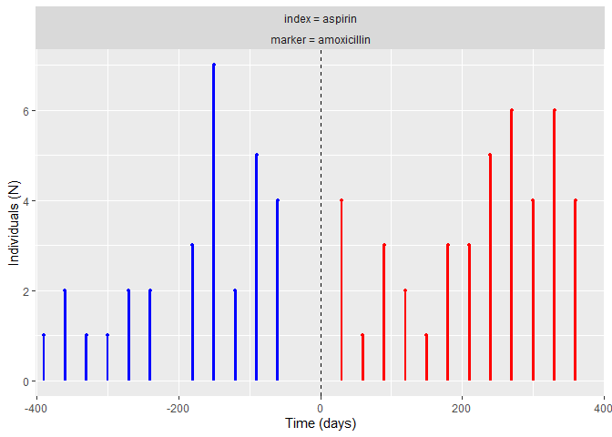

```r
plotTemporalSymmetry(result = temporal_symmetry)
```

Next, we will use the `summariseSequenceRatios()` function to get the crude sequence ratios, adjusted sequence ratios, and the corresponding confidence intervals.

```r
sequence_ratio <- summariseSequenceRatios(cohort = cdm$intersect)
```

Finally, we can visualise the results using `tableSequenceRatios()`:

```r
tableSequenceRatios(result = sequence_ratio)
```

| Index cohort name | Variable name | Estimate name | Marker cohort name amoxicillin |
| --- | --- | --- | --- |
| GiBleed |  |  |  |
| aspirin | index | N (%) | 42 (58.30%) |
|  | marker | N (%) | 30 (41.70%) |
|  | null | SR | 1.04 |
|  | crude | SR [CI 95%] | 1.40 [0.88 - 2.25] |
|  | adjusted | SR [CI 95%] | 1.34 [0.84 - 2.15] |

Or create a plot with the adjusted sequence ratios:

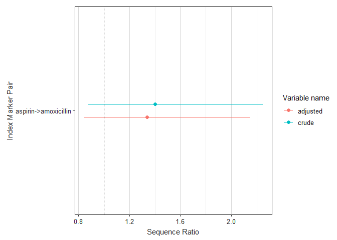

```r
plotSequenceRatios(result = sequence_ratio)
```

## As a diagram

Diagrammatically, the work flow using CohortSymmetry resembles the following flow chart:

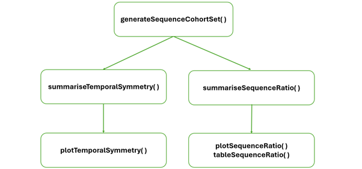